# Prosper Loan Dataset Exploration

## Preliminary Wrangling

> This document explores a data set of peer-to-peer lending marketplace that offers personal loans for borrowers with good credit and high income.

```python
# import all packages and set plots to be embedded inline
import numpy as np
import pandas as pd
import matplotlib.pyplot as plt
import seaborn as sb

%matplotlib inline
```

> Load in your dataset and describe its properties through the questions below. Try and motivate your exploration goals through this section.

```python
# Load data into pandas dataframe
loan_df = pd.read_csv('prosperLoanData.csv')
```

```python
# View first five rows of data
loan_df.head()
```

|  | ListingKey | ListingNumber | ListingCreationDate | CreditGrade | Term | LoanStatus | ClosedDate | BorrowerAPR | BorrowerRate | LenderYield | ... | LP_ServiceFees | LP_CollectionFees | LP_GrossPrincipalLoss | LP_NetPrincipalLoss | LP_NonPrincipalRecoverypayments | PercentFunded | Recommendations | InvestmentFromFriendsCount | InvestmentFromFriendsAmount | Investors |
| --- | --- | --- | --- | --- | --- | --- | --- | --- | --- | --- | --- | --- | --- | --- | --- | --- | --- | --- | --- | --- | --- |
| 0 | 1021339766868145413AB3B | 193129 | 2007-08-26 19:09:29.263000000 | C | 36 | Completed | 2009-08-14 00:00:00 | 0.16516 | 0.1580 | 0.1380 | ... | -133.18 | 0.0 | 0.0 | 0.0 | 0.0 | 1.0 | 0 | 0 | 0.0 | 258 |
| 1 | 10273602499503308B223C1 | 1209647 | 2014-02-27 08:28:07.900000000 | NaN | 36 | Current | NaN | 0.12016 | 0.0920 | 0.0820 | ... | 0.00 | 0.0 | 0.0 | 0.0 | 0.0 | 1.0 | 0 | 0 | 0.0 | 1 |
| 2 | 0EE9337825851032864889A | 81716 | 2007-01-05 15:00:47.090000000 | HR | 36 | Completed | 2009-12-17 00:00:00 | 0.28269 | 0.2750 | 0.2400 | ... | -24.20 | 0.0 | 0.0 | 0.0 | 0.0 | 1.0 | 0 | 0 | 0.0 | 41 |
| 3 | 0EF5356002482715299901A | 658116 | 2012-10-22 11:02:35.010000000 | NaN | 36 | Current | NaN | 0.12528 | 0.0974 | 0.0874 | ... | -108.01 | 0.0 | 0.0 | 0.0 | 0.0 | 1.0 | 0 | 0 | 0.0 | 158 |
| 4 | 0F023589499656230C5E3E2 | 909464 | 2013-09-14 18:38:39.097000000 | NaN | 36 | Current | NaN | 0.24614 | 0.2085 | 0.1985 | ... | -60.27 | 0.0 | 0.0 | 0.0 | 0.0 | 1.0 | 0 | 0 | 0.0 | 20 |

5 rows × 81 columns

```python
# Check dataframe's shape
loan_df.shape
```

```
(113937, 81)
```

```python
# Check dataframe's properties
loan_df.info()
```

```
<class 'pandas.core.frame.DataFrame'>
RangeIndex: 113937 entries, 0 to 113936
Data columns (total 81 columns):
ListingKey                             113937 non-null object
ListingNumber                          113937 non-null int64
ListingCreationDate                    113937 non-null object
CreditGrade                            28953 non-null object
Term                                   113937 non-null int64
LoanStatus                             113937 non-null object
ClosedDate                             55089 non-null object
BorrowerAPR                            113912 non-null float64
BorrowerRate                           113937 non-null float64
LenderYield                            113937 non-null float64
EstimatedEffectiveYield                84853 non-null float64
EstimatedLoss                          84853 non-null float64
EstimatedReturn                        84853 non-null float64
ProsperRating (numeric)                84853 non-null float64
ProsperRating (Alpha)                  84853 non-null object
ProsperScore                           84853 non-null float64
ListingCategory (numeric)              113937 non-null int64
BorrowerState                          108422 non-null object
Occupation                             110349 non-null object
EmploymentStatus                       111682 non-null object
EmploymentStatusDuration               106312 non-null float64
IsBorrowerHomeowner                    113937 non-null bool
CurrentlyInGroup                       113937 non-null bool
GroupKey                               13341 non-null object
DateCreditPulled                       113937 non-null object
CreditScoreRangeLower                  113346 non-null float64
CreditScoreRangeUpper                  113346 non-null float64
FirstRecordedCreditLine                113240 non-null object
CurrentCreditLines                     106333 non-null float64
OpenCreditLines                        106333 non-null float64
TotalCreditLinespast7years             113240 non-null float64
OpenRevolvingAccounts                  113937 non-null int64
OpenRevolvingMonthlyPayment            113937 non-null float64
InquiriesLast6Months                   113240 non-null float64
TotalInquiries                         112778 non-null float64
CurrentDelinquencies                   113240 non-null float64
AmountDelinquent                       106315 non-null float64
```

[output cut: 31 more lines]

```
LP_CustomerPayments                    113937 non-null float64
LP_CustomerPrincipalPayments           113937 non-null float64
LP_InterestandFees                     113937 non-null float64
LP_ServiceFees                         113937 non-null float64
LP_CollectionFees                      113937 non-null float64
LP_GrossPrincipalLoss                  113937 non-null float64
LP_NetPrincipalLoss                    113937 non-null float64
LP_NonPrincipalRecoverypayments        113937 non-null float64
PercentFunded                          113937 non-null float64
Recommendations                        113937 non-null int64
InvestmentFromFriendsCount             113937 non-null int64
InvestmentFromFriendsAmount            113937 non-null float64
Investors                              113937 non-null int64
dtypes: bool(3), float64(50), int64(11), object(17)
memory usage: 68.1+ MB
```

```python
# View value count for loan status
loan_df['LoanStatus'].value_counts()
```

```
Current                   56576
Completed                 38074
Chargedoff                11992
Defaulted                  5018
Past Due (1-15 days)        806
Past Due (31-60 days)       363
Past Due (61-90 days)       313
Past Due (91-120 days)      304
Past Due (16-30 days)       265
FinalPaymentInProgress      205
Past Due (>120 days)         16
Cancelled                     5
Name: LoanStatus, dtype: int64
```

```python
# View value count for Term
loan_df.Term.value_counts()
```

```
36    87778
60    24545
12     1614
Name: Term, dtype: int64
```

```python
# View value count for homeowners
loan_df.IsBorrowerHomeowner.value_counts()
```

```
True     57478
False    56459
Name: IsBorrowerHomeowner, dtype: int64
```

```python
# View value count for rating
loan_df['ProsperRating (Alpha)'].value_counts()
```

```
C     18345
B     15581
A     14551
D     14274
E      9795
HR     6935
AA     5372
Name: ProsperRating (Alpha), dtype: int64
```

```python
# View value count for employment status
loan_df.EmploymentStatus.value_counts()
```

```
Employed         67322
Full-time        26355
Self-employed     6134
Not available     5347
Other             3806
Part-time         1088
Not employed       835
Retired            795
Name: EmploymentStatus, dtype: int64
```

```python
# Check data's descriptive statistics
loan_df.describe()
```

|  | ListingNumber | Term | BorrowerAPR | BorrowerRate | LenderYield | EstimatedEffectiveYield | EstimatedLoss | EstimatedReturn | ProsperRating (numeric) | ProsperScore | ... | LP_ServiceFees | LP_CollectionFees | LP_GrossPrincipalLoss | LP_NetPrincipalLoss | LP_NonPrincipalRecoverypayments | PercentFunded | Recommendations | InvestmentFromFriendsCount | InvestmentFromFriendsAmount | Investors |
| --- | --- | --- | --- | --- | --- | --- | --- | --- | --- | --- | --- | --- | --- | --- | --- | --- | --- | --- | --- | --- | --- |
| count | 1.139370e+05 | 113937.000000 | 113912.000000 | 113937.000000 | 113937.000000 | 84853.000000 | 84853.000000 | 84853.000000 | 84853.000000 | 84853.000000 | ... | 113937.000000 | 113937.000000 | 113937.000000 | 113937.000000 | 113937.000000 | 113937.000000 | 113937.000000 | 113937.000000 | 113937.000000 | 113937.000000 |
| mean | 6.278857e+05 | 40.830248 | 0.218828 | 0.192764 | 0.182701 | 0.168661 | 0.080306 | 0.096068 | 4.072243 | 5.950067 | ... | -54.725641 | -14.242698 | 700.446342 | 681.420499 | 25.142686 | 0.998584 | 0.048027 | 0.023460 | 16.550751 | 80.475228 |
| std | 3.280762e+05 | 10.436212 | 0.080364 | 0.074818 | 0.074516 | 0.068467 | 0.046764 | 0.030403 | 1.673227 | 2.376501 | ... | 60.675425 | 109.232758 | 2388.513831 | 2357.167068 | 275.657937 | 0.017919 | 0.332353 | 0.232412 | 294.545422 | 103.239020 |
| min | 4.000000e+00 | 12.000000 | 0.006530 | 0.000000 | -0.010000 | -0.182700 | 0.004900 | -0.182700 | 1.000000 | 1.000000 | ... | -664.870000 | -9274.750000 | -94.200000 | -954.550000 | 0.000000 | 0.700000 | 0.000000 | 0.000000 | 0.000000 | 1.000000 |
| 25% | 4.009190e+05 | 36.000000 | 0.156290 | 0.134000 | 0.124200 | 0.115670 | 0.042400 | 0.074080 | 3.000000 | 4.000000 | ... | -73.180000 | 0.000000 | 0.000000 | 0.000000 | 0.000000 | 1.000000 | 0.000000 | 0.000000 | 0.000000 | 2.000000 |
| 50% | 6.005540e+05 | 36.000000 | 0.209760 | 0.184000 | 0.173000 | 0.161500 | 0.072400 | 0.091700 | 4.000000 | 6.000000 | ... | -34.440000 | 0.000000 | 0.000000 | 0.000000 | 0.000000 | 1.000000 | 0.000000 | 0.000000 | 0.000000 | 44.000000 |
| 75% | 8.926340e+05 | 36.000000 | 0.283810 | 0.250000 | 0.240000 | 0.224300 | 0.112000 | 0.116600 | 5.000000 | 8.000000 | ... | -13.920000 | 0.000000 | 0.000000 | 0.000000 | 0.000000 | 1.000000 | 0.000000 | 0.000000 | 0.000000 | 115.000000 |
| max | 1.255725e+06 | 60.000000 | 0.512290 | 0.497500 | 0.492500 | 0.319900 | 0.366000 | 0.283700 | 7.000000 | 11.000000 | ... | 32.060000 | 0.000000 | 25000.000000 | 25000.000000 | 21117.900000 | 1.012500 | 39.000000 | 33.000000 | 25000.000000 | 1189.000000 |

8 rows × 61 columns

```python
# Convert listing creation date column to datetime
loan_df['ListingCreationDate'] = pd.to_datetime(loan_df['ListingCreationDate'])
```

```python
# Create a new column year and extract year from List creation date column
loan_df['year'] = pd.DatetimeIndex(loan_df['ListingCreationDate']).year
loan_df.head()
```

|  | ListingKey | ListingNumber | ListingCreationDate | CreditGrade | Term | LoanStatus | ClosedDate | BorrowerAPR | BorrowerRate | LenderYield | ... | LP_CollectionFees | LP_GrossPrincipalLoss | LP_NetPrincipalLoss | LP_NonPrincipalRecoverypayments | PercentFunded | Recommendations | InvestmentFromFriendsCount | InvestmentFromFriendsAmount | Investors | year |
| --- | --- | --- | --- | --- | --- | --- | --- | --- | --- | --- | --- | --- | --- | --- | --- | --- | --- | --- | --- | --- | --- |
| 0 | 1021339766868145413AB3B | 193129 | 2007-08-26 19:09:29.263 | C | 36 | Completed | 2009-08-14 00:00:00 | 0.16516 | 0.1580 | 0.1380 | ... | 0.0 | 0.0 | 0.0 | 0.0 | 1.0 | 0 | 0 | 0.0 | 258 | 2007 |
| 1 | 10273602499503308B223C1 | 1209647 | 2014-02-27 08:28:07.900 | NaN | 36 | Current | NaN | 0.12016 | 0.0920 | 0.0820 | ... | 0.0 | 0.0 | 0.0 | 0.0 | 1.0 | 0 | 0 | 0.0 | 1 | 2014 |
| 2 | 0EE9337825851032864889A | 81716 | 2007-01-05 15:00:47.090 | HR | 36 | Completed | 2009-12-17 00:00:00 | 0.28269 | 0.2750 | 0.2400 | ... | 0.0 | 0.0 | 0.0 | 0.0 | 1.0 | 0 | 0 | 0.0 | 41 | 2007 |
| 3 | 0EF5356002482715299901A | 658116 | 2012-10-22 11:02:35.010 | NaN | 36 | Current | NaN | 0.12528 | 0.0974 | 0.0874 | ... | 0.0 | 0.0 | 0.0 | 0.0 | 1.0 | 0 | 0 | 0.0 | 158 | 2012 |
| 4 | 0F023589499656230C5E3E2 | 909464 | 2013-09-14 18:38:39.097 | NaN | 36 | Current | NaN | 0.24614 | 0.2085 | 0.1985 | ... | 0.0 | 0.0 | 0.0 | 0.0 | 1.0 | 0 | 0 | 0.0 | 20 | 2013 |

5 rows × 82 columns

```python
# View value count for year
loan_df.year.value_counts()
```

```
2013    35413
2012    19556
2007    11557
2011    11442
2008    11263
2014    10734
2006     6213
2010     5530
2009     2206
2005       23
Name: year, dtype: int64
```

### What is the structure of your dataset?

> There are 113937 customers with 81 variables.

### What is/are the main feature(s) of interest in your dataset?

> The main features of interest in my dataset are:
> - **LoanStatus:** The current status of the loan: Cancelled, Chargedoff, Completed, Current, Defaulted, FinalPaymentInProgress, PastDue. The PastDue status will be accompanied by a delinquency bucket.
> - **BorrowerAPR:** The Borrower's Annual Percentage Rate (APR) for the loan.
> - **EmoloymentStatus:** The employment status of the borrower at the time they posted the listing.
> - **ProsperRating:** The Prosper Rating assigned at the time the listing was created between AA - HR. Applicable for loans originated after July 2009.
> - **ProsperScore:** A custom risk score built using historical Prosper data. The score ranges from 1-10, with 10 being the best, or lowest risk score. Applicable for loans originated after July 2009.
> - **LoanOriginalAmount:** The origination amount of the loan.
> - **StatedMonthlyIncome:** The monthly income the borrower stated at the time the listing was created.
> - **Term:** The length of the loan expressed in months.
> - **IsBorrowerHomeowner:** A Borrower will be classified as a homowner if they have a mortgage on their credit profile or provide documentation confirming they are a homeowner.

### What features in the dataset do you think will help support your investigation into your feature(s) of interest?

> My aim for this project is to investigate the factors that impact the borrowers APR. I will use the variables selected above to generate insights to come to a conclusion. My expectation is that the amount given to the borrowers is part of the determinant, however, i am going to explore other variables.

## Univariate Exploration

> In this section, investigate distributions of individual variables. If you see unusual points or outliers, take a deeper look to clean things up and prepare yourself to look at relationships between variables.

```python
# Select features of interest and put them in a new data frame
columns = ['LoanStatus', 'BorrowerAPR', 'LoanOriginalAmount', 'StatedMonthlyIncome', 'ProsperRating (Alpha)',
        'EmploymentStatus', 'Term', 'IsBorrowerHomeowner', 'year']
df_sub = loan_df[columns]
```

```python
# View descriptive statistics of the chosen variables
df_sub.describe()
```

|  | BorrowerAPR | LoanOriginalAmount | StatedMonthlyIncome | Term | year |
| --- | --- | --- | --- | --- | --- |
| count | 113912.000000 | 113937.00000 | 1.139370e+05 | 113937.000000 | 113937.000000 |
| mean | 0.218828 | 8337.01385 | 5.608026e+03 | 40.830248 | 2011.012481 |
| std | 0.080364 | 6245.80058 | 7.478497e+03 | 10.436212 | 2.504353 |
| min | 0.006530 | 1000.00000 | 0.000000e+00 | 12.000000 | 2005.000000 |
| 25% | 0.156290 | 4000.00000 | 3.200333e+03 | 36.000000 | 2008.000000 |
| 50% | 0.209760 | 6500.00000 | 4.666667e+03 | 36.000000 | 2012.000000 |
| 75% | 0.283810 | 12000.00000 | 6.825000e+03 | 36.000000 | 2013.000000 |
| max | 0.512290 | 35000.00000 | 1.750003e+06 | 60.000000 | 2014.000000 |

## Note

Since BorrowerAPR is the main interest of this investigation, and there are null values in the column, i will drop the rows with null values in the BorrowerAPR column.

```python
# Drop rows with missing borrower APR information
df_sub = df_sub[~df_sub.BorrowerAPR.isna()]
```

## 1) Exploring the loan status column

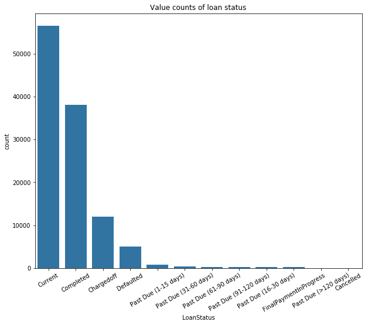

```python
# Plot a bar chart for the loan status column
plt.figure(figsize=(10, 8))
base_color = sb.color_palette()[0]
status_order = df_sub['LoanStatus'].value_counts().index
sb.countplot(data = df_sub, x = 'LoanStatus', color = base_color, order = status_order)
plt.xticks(rotation = 30)
plt.title('Value counts of loan status');
```

## Insights

- The plot above shows the count of each loan status type. The current status type has the highest count, followed by the completed status type, while the chargeoff status type has the third highest count.
- Next up, i will explore the borrowers APR variable.

## 2) Distribution of borrower APR

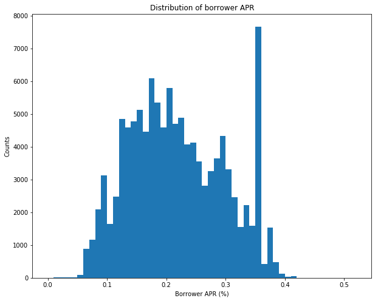

```python
plt.figure(figsize = [10, 8]) # larger figure size for subplots

# histogram plot for borrower APR
bin_size = 0.01
bin_edges = np.arange(0, df_sub['BorrowerAPR'].max()+bin_size, bin_size)
plt.hist(data = df_sub, x = 'BorrowerAPR', bins = bin_edges)
plt.xlabel('Borrower APR (%)')
plt.ylabel('Counts')
plt.title('Distribution of borrower APR');
```

## Insight

- The BorrowerAPR column distribution has multi modes, i.e., multi-modal. The distribution has peaks in several loactions with the highest peak around the 0.36 mark.
- Next up, I will explore the original loan amount.

## 3) Exploring the Original loan amount column

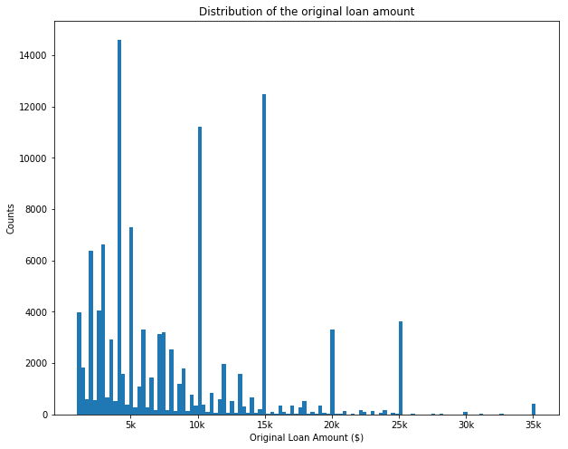

```python
plt.figure(figsize = [10, 8]) # larger figure size for subplots

# histogram plot for Original loan amount

bin_edges = np.arange(1000, df_sub['LoanOriginalAmount'].max()+300, 300)
plt.hist(data = df_sub, x = 'LoanOriginalAmount', bins = bin_edges)
plt.xlabel('Original Loan Amount ($)')
plt.xticks([5e3, 1e4, 15e3, 2e4, 25e3, 3e4, 35e3], ['5k', '10k', '15k', '20k', '25k', '30k', '35k'])
plt.ylabel('Counts')
plt.title('Distribution of the original loan amount');
```

## Insight

- The distribution of the origial loan amount column shows that the high peaks are generally around that marks where the loan amount is in multiples of 1000, with the highest peaks in the 4000, 5000, 10000, and 15000 marks.
- I will explore the stated monthly income.

## 4) Exploring the stated monthly income column

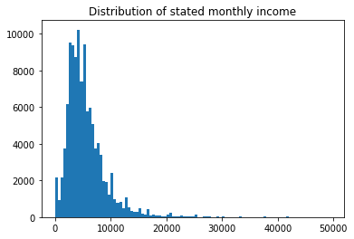

```python
# Plot distribution of the stated monthly income
bins = np.arange(0, 50000, 500)
plt.hist(data = df_sub, x = 'StatedMonthlyIncome', bins=bins)
plt.title('Distribution of stated monthly income');
```

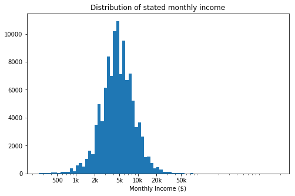

```python
# Since there's a long tail in the distribution, i'll put it on a log scale instead
log_binsize = 0.05
bins = 10 ** np.arange(2.4, np.log10(df_sub['StatedMonthlyIncome'].max())+log_binsize, log_binsize)

plt.figure(figsize=[8, 5])
plt.hist(data = df_sub, x = 'StatedMonthlyIncome', bins = bins)
plt.xscale('log')
plt.xticks([500, 1e3, 2e3, 5e3, 1e4, 2e4, 5e4], [500, '1k', '2k', '5k', '10k', '20k', '50k'])
plt.xlabel('Monthly Income ($)')
plt.title('Distribution of stated monthly income')
plt.show();
```

## Insight

- The distribution of the stated monthly income shows that majority of the monthly income is less than 10000. The distribution is alos right skewed with a long tail. I put it on a log scale, the log transformation essentially reels these values into the center of the distribution making it look more like a Normal distribution. This transformation shows clearly the highest peak is around the 5k mark, and most borrowers earn between 3k and 8k.
- Next up, I will explore the employment status column.

## 5) Exploring employment status column

```python
# Convert employment status column to categorical data type
df_sub['EmploymentStatus'] = df_sub['EmploymentStatus'].astype('category')
```

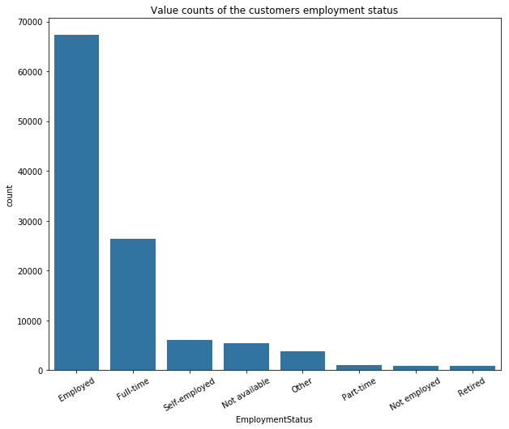

```python
# Plot a bar chart for the employment status column
plt.figure(figsize=(10, 8))
base_color = sb.color_palette()[0]
status_order = df_sub['EmploymentStatus'].value_counts().index
sb.countplot(data = df_sub, x = 'EmploymentStatus', color = base_color, order = status_order)
plt.xticks(rotation = 30)
plt.title('Value counts of the customers employment status');
```

## 6) Exploring the ProsperRating column

```python
# Convert prosper rating (Alpha) column to categorical data type
rating_order = ['AA', 'A', 'B', 'C', 'D', 'E', 'HR']
ratings_ordered = pd.api.types.CategoricalDtype(ordered=True, categories = rating_order)

df_sub['ProsperRating (Alpha)'] = df_sub['ProsperRating (Alpha)'].astype(ratings_ordered)
```

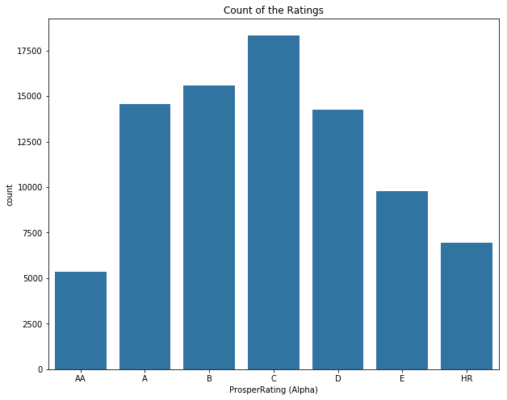

```python
# Plot a bar charts for the prosper score and prosper rating (Alpha) columns
plt.figure(figsize=(10, 8))
default_color = sb.color_palette()[0]
sb.countplot(data = df_sub, x = 'ProsperRating (Alpha)', color = default_color)
plt.title('Count of the Ratings')

plt.show();
```

## 7) Exploring the term column

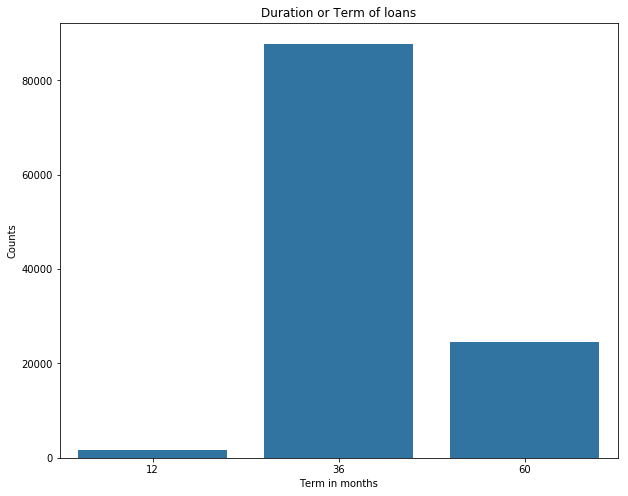

```python
# Plot a bar chart for the loan status column
plt.figure(figsize=(10, 8))
base_color = sb.color_palette()[0]
sb.countplot(data = df_sub, x = 'Term', color = base_color)
plt.title('Duration or Term of loans')
plt.xlabel('Term in months')
plt.ylabel('Counts');
```

## Insight

- The plot above shows that most of the borrowers loan term is 36 months, followed by 60 month, while the minority have a short term loan of 12 months.
- Next up, I will explore the homeowner column.

## 8) Exploring the homeowner column

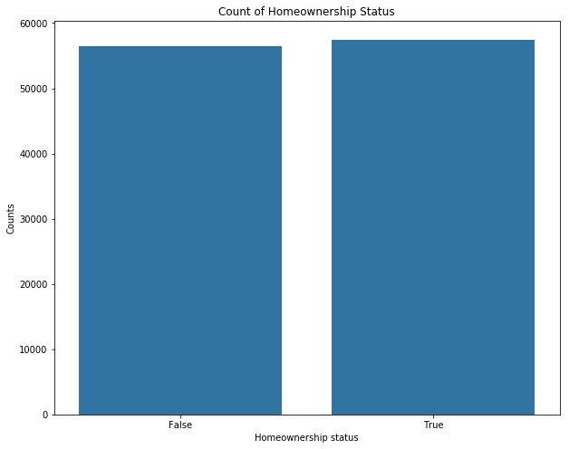

```python
# Plot a bar chart for the loan status column
plt.figure(figsize=(10, 8))
base_color = sb.color_palette()[0]
sb.countplot(data = df_sub, x = 'IsBorrowerHomeowner', color = base_color)
plt.title('Count of Homeownership Status')
plt.xlabel('Homeownership status')
plt.ylabel('Counts');
```

## Insight

- Even though the counts for both home owners and non-homeowners are close, the plot shows that majority of the borrowers are homeowners.

> Make sure that, after every plot or related series of plots, that you include a Markdown cell with comments about what you observed, and what you plan on investigating next.

### Of the features you investigated, were there any unusual distributions? Did you perform any operations on the data to tidy, adjust, or change the form of the data? If so, why did you do this?

> My main variable of interest is the BorrowerAPR, and since the column has some null values, i dropped the rows with null values in the BorrowedAPR column.

## Bivariate Exploration

> In this section, investigate relationships between pairs of variables in your data. Make sure the variables that you cover here have been introduced in some fashion in the previous section (univariate exploration).

To start the bivariate exploration, i'm going to do a pairwise correlation of my numerical variables.

```python
# Separate the variables in different lists
num_variables = ['BorrowerAPR', 'LoanOriginalAmount', 'StatedMonthlyIncome']
cat_variables = ['ProsperRating (Alpha)', 'Term', 'EmploymentStatus']
```

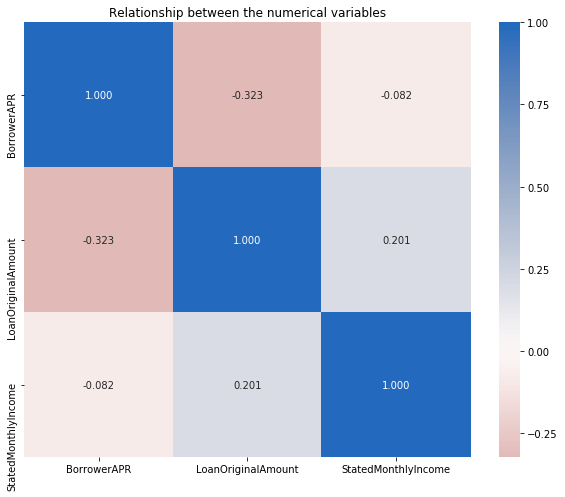

```python
# Plot correlation heatmap of the numerical variables
plt.figure(figsize=(10, 8))
sb.heatmap(df_sub[num_variables].corr(), annot = True, fmt = '.3f', cmap = 'vlag_r', center = 0)
plt.title('Relationship between the numerical variables');
```

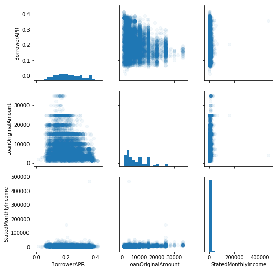

```python
# plot matrix: sample 10000 diamonds so that plots are clearer and they render faster
samples = np.random.choice(df_sub.shape[0], 10000, replace = False)
loans_samp = df_sub.loc[samples,:]

g = sb.PairGrid(data = loans_samp, vars = num_variables)
g = g.map_diag(plt.hist, bins = 20)
g.map_offdiag(plt.scatter, alpha=1/20);
```

## Insight

The heat map and pair grid plot shows the relationships between the numerical variables, BorrowerAPR, LoanOriginalAmount, and StatedMonthlyIncome. The borrowerAPR has a negative relationship of -0.323 with the LoanOriginalAmount. The BorrowerAPR also has a weak negative relationship of -0.082 with the StatedMonthlyIncome. This means that there is an inverse relationship between the BorrowerAPR and the other variables. However, there is a positive but weak relationship between the MonthlyStatedIncome and the LoanOriginalAmount.

In the next plot, i will check how the BorrowerAPR, and LoanOriginalAmount correlate with the categorical variables.

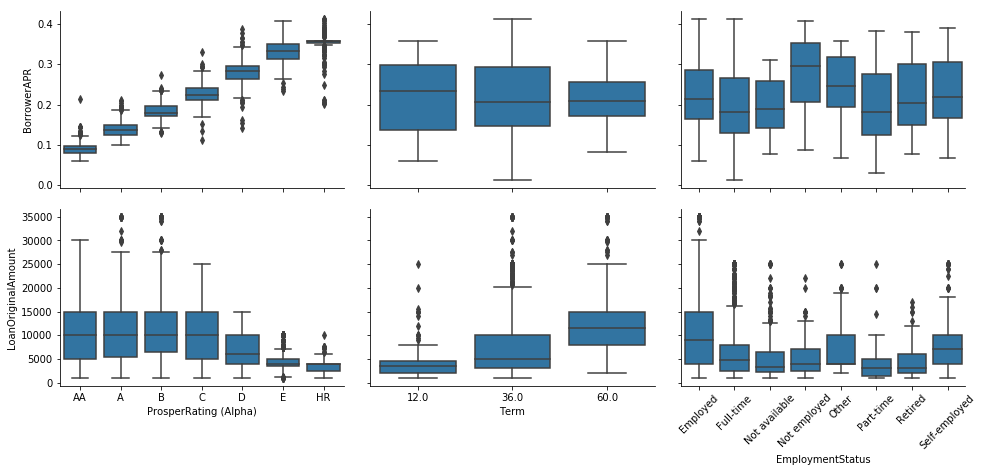

```python
# plot matrix of numeric features against categorical features.
# can use a larger sample since there are fewer plots and they're simpler in nature.
def boxgrid(x, y, **kwargs):
    """ Quick hack for creating box plots with seaborn's PairGrid. """
    default_color = sb.color_palette()[0]
    sb.boxplot(x, y, color = default_color)

plt.figure(figsize=(10, 8))
g = sb.PairGrid(data = loans_samp, y_vars = ['BorrowerAPR', 'LoanOriginalAmount'], x_vars = cat_variables,
                size = 3, aspect = 1.5, height = 4)
g.map(boxgrid)
plt.xticks(rotation=45);
```

In the boxgrids above, it appears that there are some negative relationships between the categorical variables and the two numeric variables used for comparison, i.e., BorrowerAPR, and LoanOriginalAmount. The borrowers associated with high risks were given the least amount in loans and higher APR. While the borrowers with the least risk got higher amount in loans and lower APR. The relationship between the LoanOriginalAmount and the term reveals that there is a progression inthe term based on the amount given in loans, this means that small amounts were given to the people with a 12 months term, and as the term increases the amount increases, however, there are some exceptions. Employed borrowers, self-employed borrowers, borrowers whose employment status was categorized under others, and full-time borrowers got higher loan amounts that part-time, and unemployed borrowers.

let's look at relationships between the three categorical features, and how the loan status interacts with this variables.

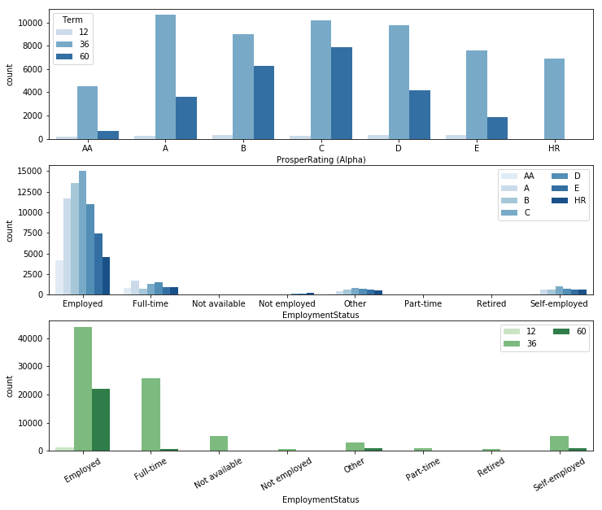

```python
# Plot the interactions between the categorical variables
# since there are only three subplots to create, using the full data should be fine.
plt.figure(figsize = [12, 10])

# subplot 1: ProsperRating vs Term
plt.subplot(3, 1, 1)
sb.countplot(data = df_sub, x = 'ProsperRating (Alpha)', hue = 'Term', palette = 'Blues')

# subplot 2: ProsperRating vs. EmploymentStatus
ax = plt.subplot(3, 1, 2)
sb.countplot(data = df_sub, x = 'EmploymentStatus', hue = 'ProsperRating (Alpha)', palette = 'Blues')
ax.legend(ncol = 2) # re-arrange legend to reduce overlapping

# subplot 3: EmploymentStatus vs. Term, use different color palette
ax = plt.subplot(3, 1, 3)
sb.countplot(data = df_sub, x = 'EmploymentStatus', hue = 'Term', palette = 'Greens')
ax.legend(loc = 1, ncol = 2) # re-arrange legend to remove overlapping

plt.xticks(rotation=30)
plt.show()
```

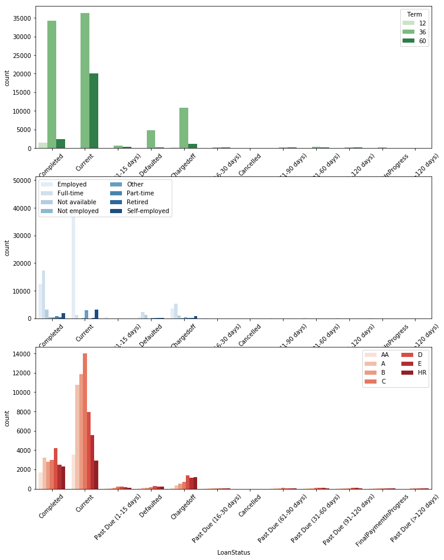

```python
# Plot the interactions between the loan status and the categorical variables
plt.figure(figsize = [12, 15])

# subplot 1: LoanStatus vs Term
plt.subplot(3, 1, 1)
sb.countplot(data = df_sub, x = 'LoanStatus', hue = 'Term', palette = 'Greens')
plt.xticks(rotation=45)

# subplot 2: LoanStatus vs. EmploymentStatus
ax = plt.subplot(3, 1, 2)
sb.countplot(data = df_sub, x = 'LoanStatus', hue = 'EmploymentStatus', palette = 'Blues')
ax.legend(ncol = 2) # re-arrange legend to reduce overlapping
plt.xticks(rotation = 45)

# subplot 3: EmploymentStatus vs. Term, use different color palette
ax = plt.subplot(3, 1, 3)
sb.countplot(data = df_sub, x = 'LoanStatus', hue = 'ProsperRating (Alpha)', palette = 'Reds')
ax.legend(loc = 1, ncol = 2) # re-arrange legend to remove overlapping
plt.xticks(rotation=45)

plt.show()
```

## Insight

The relationship between EmploymentStatus and ProsperRating reveals that some borrowers that are employed, self-employed, borrowers with full-time jobs, and borrowers classified under others are associated with high risk. There is also not enough information for borrowers in the part-time, retired, not-available, and not employed categories to draw insights.

The interaction of the loan status with these categorical variables shows that there is not enough information on borrowers with past due status. However, some borrowers have completed their payments irrespective of the term, employment status, and risk level. It is actually interesting that borrowers with high risk level completed their loans and some of them are current with their payments.

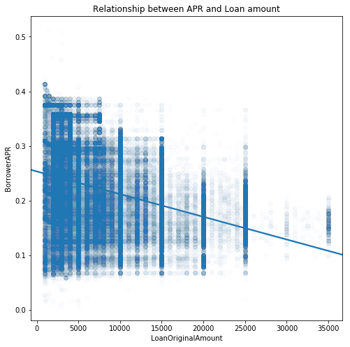

```python
# Plot a scatter plot for loan original amount and borrower APR
plt.figure(figsize = [8, 8])
sb.regplot(data = df_sub, x = 'LoanOriginalAmount', y = 'BorrowerAPR', scatter_kws={'alpha':0.01})
plt.title('Relationship between APR and Loan amount');
```

## Insight

There appears to be a negative linear relationship between the LoanOrignalAmount and BorrowerAPR. However, the pattern shows that the range of the APR is reduces as the Loan amount increases. The plot also shows that the range of APR at different Loan amount is wide.

Next up, I'll explore the pattern of the borrower APR over the years.

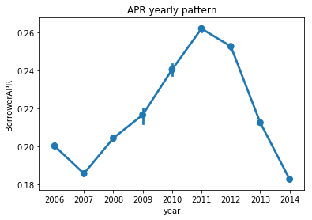

```python
# plot the pointplot for year vs BorrowerAPR
sb.pointplot(data = df_sub, x='year', y='BorrowerAPR')
plt.title('APR yearly pattern')
```

## Insight

The pattern of the APR shows that the year the APR was at an all time high was in 2011, while the lowest was in 2014.

### Talk about some of the relationships you observed in this part of the investigation. How did the feature(s) of interest vary with other features in the dataset?

> The borrower APR has a negative relationship with the loan original amount, and the stated monthly income. This means the relationship between the borrower APR is inverse. It also reveals the wide range of the APR at the various amount of the loans. The Prosper rating also has a very strong impact on the APR, and the loan amount.

### Did you observe any interesting relationships between the other features (not the main feature(s) of interest)?

> The relationship between the term and the rating shows that across all ratings, a large number of borrowers are on the 36 month term. The relationship between the loan status and the ratings is actually interesting because it reveals that borrowers with high risk level completed their loans and some of them are current with their payments.

## Multivariate Exploration

> Create plots of three or more variables to investigate your data even further. Make sure that your investigations are justified, and follow from your work in the previous sections.

I will be plotting a boxplot to view the pattern of borrowers APR over the years depending on if they own a home or not.

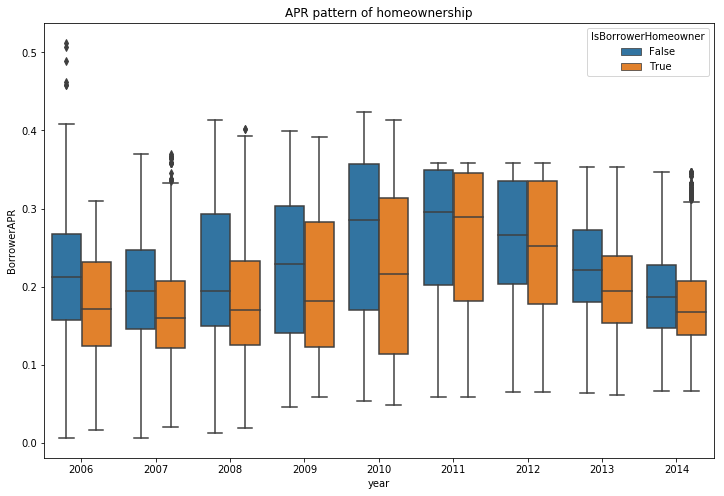

```python
# Boxplot for APR pattern between homeowners and non-homeowners
plt.figure(figsize=(12, 8))
g = sb.boxplot(data = df_sub, x='year', y='BorrowerAPR', hue='IsBorrowerHomeowner')
plt.title('APR pattern of homeownership');
```

## Insight

Next up, I will check if there were homeowners considered as high risk, and non-homeowners considered as low risk.

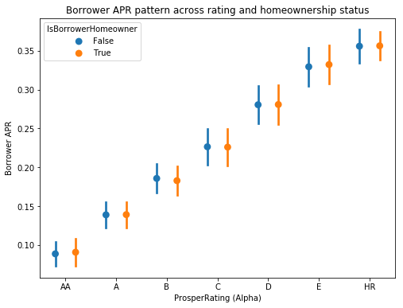

```python
# Plot for borrower APR vs homeownership status vs Prosper rating
fig = plt.figure(figsize = [8,6])
ax = sb.pointplot(data = df_sub, x = 'ProsperRating (Alpha)', y = 'BorrowerAPR', hue = 'IsBorrowerHomeowner', linestyles = '', dodge = 0.4, ci = 'sd')
plt.title('Borrower APR pattern across rating and homeownership status')
plt.ylabel('Borrower APR')
ax.set_yticklabels([],minor = True)
plt.show();
```

## Insight

The plot above reveals that some homeowners are considered as high level risk, and some non-homeowners are considered as low risk.

Next up, i will explore the APR across rating and loan terms.

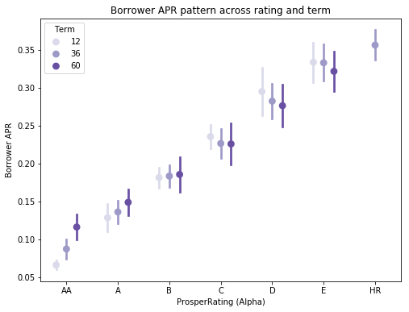

```python
# Plot for borrower APR vs Term vs Prosper Rating
fig = plt.figure(figsize = [8,6])
ax = sb.pointplot(data = df_sub, x = 'ProsperRating (Alpha)', y = 'BorrowerAPR', hue = 'Term',
           palette = 'Purples', linestyles = '', dodge = 0.4, ci = 'sd')
plt.title('Borrower APR pattern across rating and term')
plt.ylabel('Borrower APR')
ax.set_yticklabels([],minor = True)
plt.show();
```

## Insight

The point plot above reveals the pattern of the APR across the rating and loan terms. The borrowers with great rating, i.e., low risk borrowers have lower APR. The progression shows the increase in the APR as the risk level increases.

### Talk about some of the relationships you observed in this part of the investigation. Were there features that strengthened each other in terms of looking at your feature(s) of interest?

> I was curious about the criteria that affects the APR, and decided to extend the exploration to involve homeowners. This reveals that homeowners have a lower APR, The rating if the borrower also have an effect on the APR.

### Were there any interesting or surprising interactions between features?

> However, it was interesting to see that having a home does not really impact the rating, as some non-homeowners were classified under low risk level, and some homeowners were classifies as high risk level.